# Project Multivariate data Analysis

## AC ward

```r
hc3_s$ac
```

```
## [1] 0.8552635
```

The AC value is high.

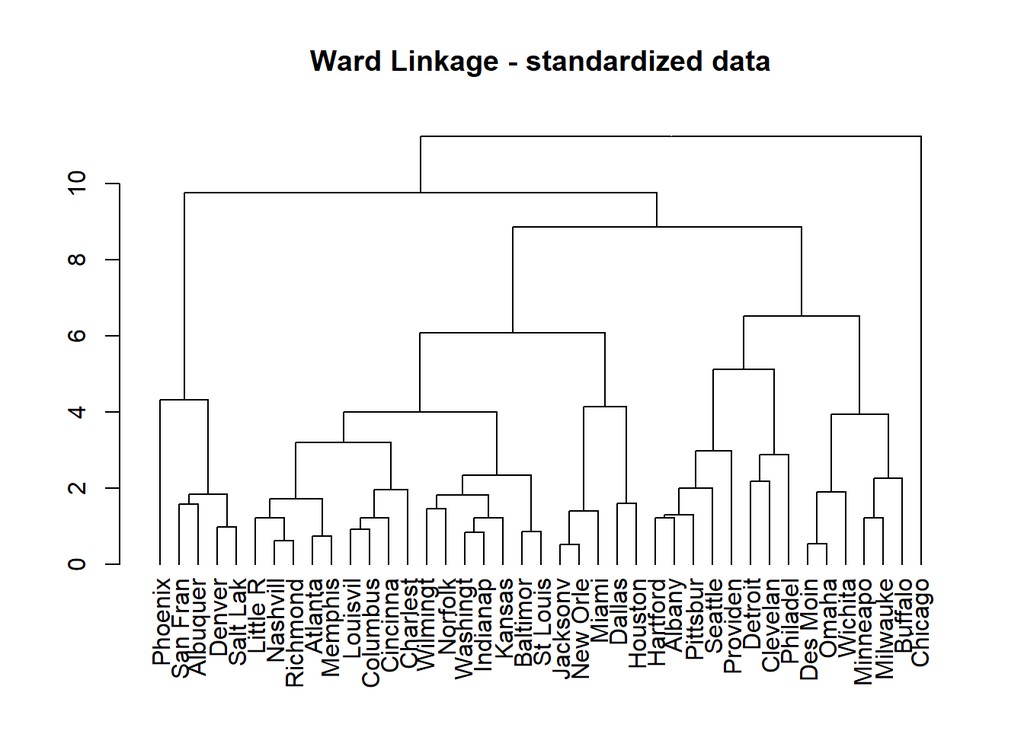

```r
#Dendrogram
dend3_s <- as.dendrogram(hc3_s)
#labels(dend1_s) <- data5$city
order_in_dend3 <- order.dendrogram(dend3_s)
labels(dend3_s) <- data5$city[order_in_dend3]
plot(dend3_s, main = "Ward Linkage - standardized data")
```

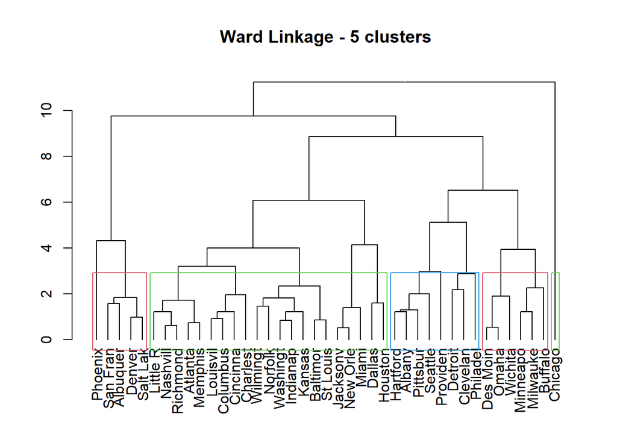

```r
plot(dend3_s, main="Ward Linkage - 5 clusters")
# k =  clusters considered
rect.hclust(hc3_s, k=5, border = 2:4)
```

## Now we can do the *Cophenetic Coefficient*. Ward

```r
#Cophenetic Coefficient
clust_ward_s <- hclust(dist_data5, method="ward")
```

```
## The "ward" method has been renamed to "ward.D"; note new "ward.D2"
```

```r
#Cophenetic matrix (delta matrix - obtained based on the dendogram)
coph_3_s <- cophenetic(clust_ward_s)

#Cophenetic coefficient
cor(dist_data5, coph_3_s)
```

```
## [1] 0.4697547
```

Using the silhouette method to determine the optimal number of clusters:

```r
library(cluster)

# Choose the range of clusters to test
k_values <- 2:6

for (k in k_values) {
  # Cut dendrogram to get cluster assignments
  clusters <- cutree(hc3_s, k = k)

  # Compute silhouette
  sil <- silhouette(clusters, dist_data5)

  # Average silhouette width
  avg_sil <- mean(sil[, 3])
  cat("k =", k, "Average silhouette width =", round(avg_sil, 3), "\n")
}
```

```
## k = 2 Average silhouette width = 0.601
## k = 3 Average silhouette width = 0.3
## k = 4 Average silhouette width = 0.244
## k = 5 Average silhouette width = 0.255
## k = 6 Average silhouette width = 0.23
```

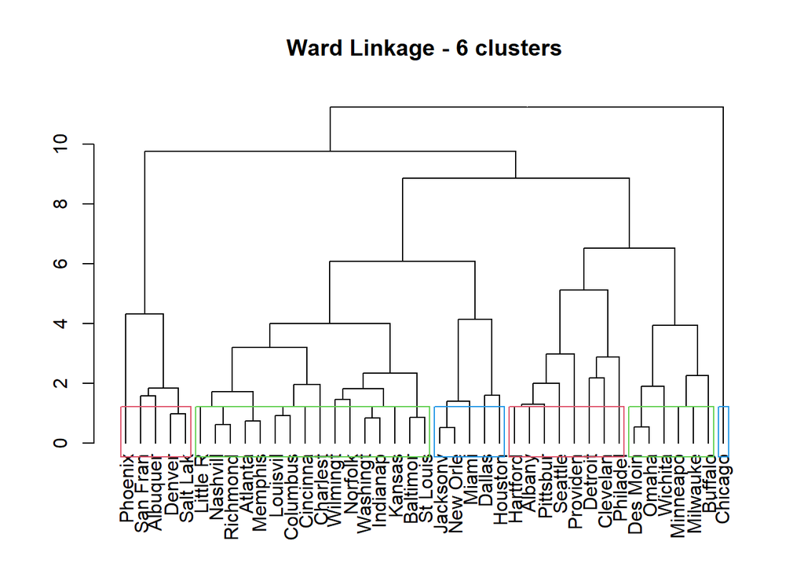

```r
plot(dend3_s, main="Ward Linkage - 6 clusters")
# k =  clusters considered
rect.hclust(hc3_s, k=6, border = 2:4)
```

**RESULT** The ward method has a much lower coefficient than the other ones.

## Cluster combination

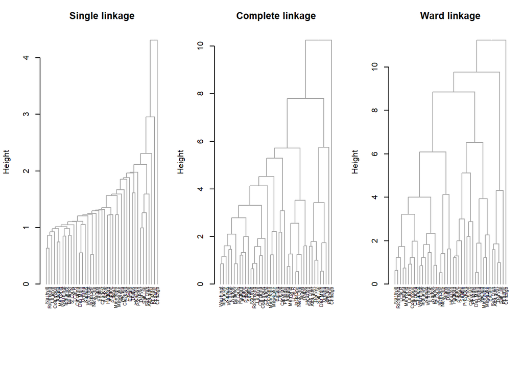

```r
# packages
library(cluster)     # agnes
library(dendextend)  # ladderize, set(..., "labels_cex")

data5_v <- scale(data5_variables)

# compute agglomerative clusterings (single, complete, ward)
hc_single   <- agnes(data5_v, method = "single")
hc_complete <- agnes(data5_v, method = "complete")
hc_ward     <- agnes(data5_v, method = "ward")   # agnes "ward"

# convert to hclust for convenience and create dendrograms
hclust_single   <- as.hclust(hc_single)
hclust_complete <- as.hclust(hc_complete)
hclust_ward     <- as.hclust(hc_ward)

dend_single   <- as.dendrogram(hclust_single)   %>% ladderize()
dend_complete <- as.dendrogram(hclust_complete) %>% ladderize()
dend_ward     <- as.dendrogram(hclust_ward)     %>% ladderize()

# set labels in plotting order and reduce label size
labels(dend_single)   <- data5$city[order.dendrogram(dend_single)]
labels(dend_complete) <- data5$city[order.dendrogram(dend_complete)]
labels(dend_ward)     <- data5$city[order.dendrogram(dend_ward)]

# smaller label text for all dendrograms
dend_single   <- set(dend_single,   "labels_cex", 0.55)
dend_complete <- set(dend_complete, "labels_cex", 0.55)
dend_ward     <- set(dend_ward,     "labels_cex", 0.55)

plot_three_dendros <- function(d1, d2, d3) {
  op <- par(mfrow = c(1, 3), mar = c(8, 4, 3, 1) + 0.1)  # extra bottom margin for labels
  plot(d1, main = "Single linkage", ylab = "Height",
       edgePar = list(col = "darkgray", lwd = 1))
  plot(d2, main = "Complete linkage", ylab = "Height",
       edgePar = list(col = "darkgray", lwd = 1))
  plot(d3, main = "Ward linkage", ylab = "Height",
       edgePar = list(col = "darkgray", lwd = 1))
  par(op)
}

# Display in the knitted report
plot_three_dendros(dend_single, dend_complete, dend_ward)
```

```r
# 2) Save identical high-resolution PNG to plots/ (re-run the same plotting code inside png())
if (!dir.exists("plots")) dir.create("plots")
png(filename = "plots/dendrograms_comparison.png", width = 2400, height = 1000, res = 300)
plot_three_dendros(dend_single, dend_complete, dend_ward)
dev.off()
```

# Cluster Analysis with the PCA Data

Add cities names´ to the pca_scores table

```r
identical(rownames(pca_scores), rownames(data5))
```

```
## [1] TRUE
```

```r
pca_scores2 <- cbind(city = data5$city, pca_scores)
```

Considering 3 principal components for the PCA data :

```r
pca_results$sdev
```

```
##    Comp.1    Comp.2    Comp.3    Comp.4    Comp.5    Comp.6    Comp.7
## 1.6517021 1.2297702 1.1810897 0.9444529 0.5888792 0.3166822 0.1597339
```

```r
pca_results$sdev[1:3]
```

```
##   Comp.1   Comp.2   Comp.3
## 1.651702 1.229770 1.181090
```

In order to perform and obtain the dendograms, we need to determine the distances (to cluster the groups).

```r
pca_cluster <- pca_scores[,1:3] ; pca_cluster
```

```
##            PC1         PC2         PC3
## 1  -2.68264965 -3.84368955  1.04536813
## 2  -1.69666795  0.47650053  0.83961298
## 3  -0.92744347 -2.20979453 -0.18149322
## 4  -0.54311446 -1.94774644 -1.21352047
## 5   0.45472289  1.08386981 -0.58246788
## 6  -0.68852272  0.62439221 -0.41615954
## 7  -0.04555952 -0.05027326  0.34988543
## 8  -1.35912964  0.92688238  1.84306708
## 9  -1.69467532  1.48949101  2.55354056
## 10 -0.61099829  0.63025982  0.97623533
## 11  7.23097079 -2.02725781  2.23562114
## 12  0.24048944  0.30539249 -0.29507787
## 13 -0.46515732 -0.14701111 -1.63953441
## 14 -0.84415913 -0.81131118 -1.12909377
```

[output cut: 27 more lines]

```r
pca_cluster2 <- pca_scores2[,1:4] ; pca_cluster2 #usar com labels das cidades
```

```
##        city         PC1         PC2         PC3
## 1   Phoenix -2.68264965 -3.84368955  1.04536813
## 2  Little R -1.69666795  0.47650053  0.83961298
## 3  San Fran -0.92744347 -2.20979453 -0.18149322
## 4    Denver -0.54311446 -1.94774644 -1.21352047
## 5  Hartford  0.45472289  1.08386981 -0.58246788
## 6  Wilmingt -0.68852272  0.62439221 -0.41615954
## 7  Washingt -0.04555952 -0.05027326  0.34988543
## 8  Jacksonv -1.35912964  0.92688238  1.84306708
## 9     Miami -1.69467532  1.48949101  2.55354056
## 10  Atlanta -0.61099829  0.63025982  0.97623533
## 11  Chicago  7.23097079 -2.02725781  2.23562114
## 12 Indianap  0.24048944  0.30539249 -0.29507787
## 13 Des Moin -0.46515732 -0.14701111 -1.63953441
## 14  Wichita -0.84415913 -0.81131118 -1.12909377
```

[output cut: 27 more lines]

```r
#dissimilarity matrix : squared euclidean distance
library(proxy)
dist_pca <- dist(pca_cluster,method="euclidean")
dist_pca
```

[output not shown]

[output cut: 191 more lines]

[output not shown]

**Let´s perform the Hierarchical Clustering for the PCA data**.

## SINGLE LINKAGE

```r
#hierarchical clustering (aglommerative) using Single Linkage
hcpca1 <- agnes(dist_pca,method="single") #agnes Computes agglomerative hierarchical clustering of the dataset.
hcpca1$merge
```

```
##       [,1] [,2]
##  [1,]  -15  -26
##  [2,]   -8  -16
##  [3,]    1  -37
##  [4,]  -10  -33
##  [5,]    4  -38
##  [6,]    5  -32
##  [7,]  -17  -21
##  [8,]   -5  -39
##  [9,]  -30  -31
## [10,]  -14  -22
## [11,]  -19  -41
## [12,]  -12  -28
## [13,]   -6    3
## [14,]  -13   10
```

[output cut: 26 more lines]

```r
#Visualize the order in which the objects, clustered, appear in the dendrogram.
hcpca1$order
```

```
##  [1]  1  2  5 39 30 31  6 15 26 37 12 28 10 33 38 32  7 40 20 17 21 24 27  4 36
## [26] 13 14 22  8 16  9  3 25 18 19 41 35 23 34 29 11
```

### AC

```r
hcpca1$ac
```

```
## [1] 0.8118718
```

### Cophenetic single

```r
clust_pca <- clustering(pca_cluster,distmethod = "euclidean",clustmethod = "single")
clust_pca$cophenetic
```

```
## [1] 0.8529945
```

### Dendogram

```r
dend1_pca <- as.dendrogram(hcpca1)
order_in_dend <- order.dendrogram(dend1_pca)
labels(dend1_pca) <- data5$city[order_in_dend]
dend1_pca
```

```
## 'dendrogram' with 2 branches and 41 members total, at height 4.290389
```

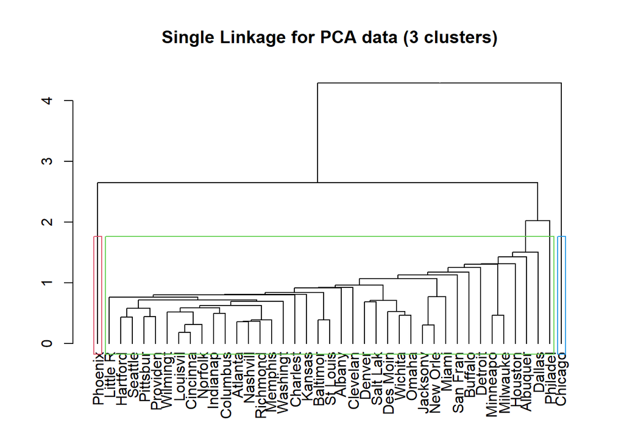

```r
plot(dend1_pca,main="Single Linkage for PCA data (3 clusters)")
rect.hclust(hcpca1,k=3,border=2:4)
```

# Combination of methods PCA.

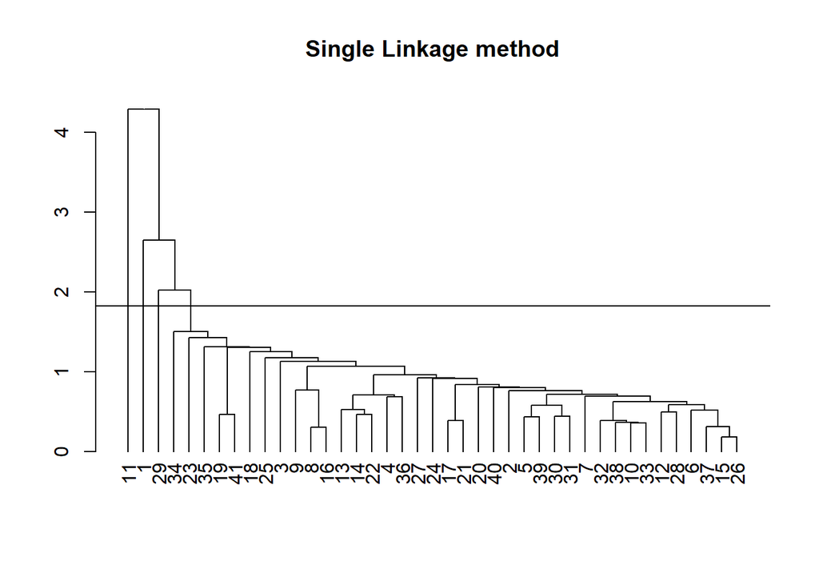

```r
plot(clust_pca,horiz=FALSE,main="Single Linkage method")
```

Considering 4 clusters:

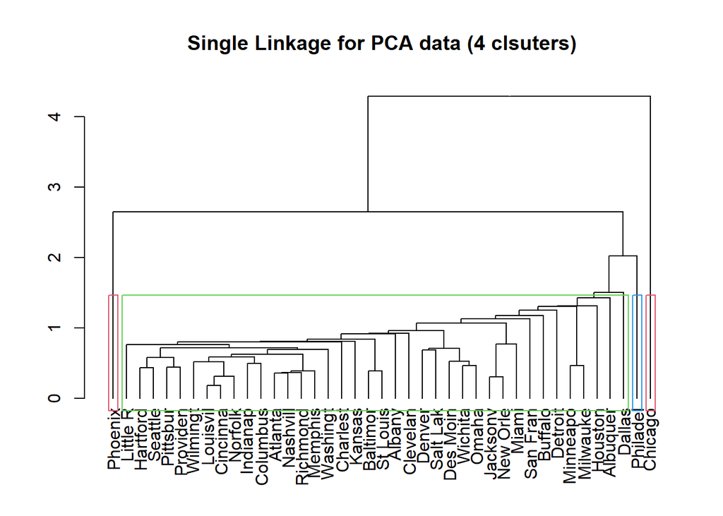

```r
order_in_dend <- order.dendrogram(dend1_pca)
labels(dend1_pca) <- data5$city[order_in_dend]
plot(dend1_pca,main="Single Linkage for PCA data (4 clsuters)")
rect.hclust(hcpca1,k=4,border=2:4)
```

#### Comparing with the Complete linkage method:

```r
hcpca2 <- agnes(pca_cluster,method="complete")
hcpca2$merge
```

```
##       [,1] [,2]
##  [1,]  -15  -26
##  [2,]   -8  -16
##  [3,]  -10  -33
##  [4,]  -17  -21
##  [5,]    1  -37
##  [6,]   -5  -39
##  [7,]  -30  -31
##  [8,]    3  -32
##  [9,]  -14  -22
## [10,]  -19  -41
## [11,]  -12  -28
## [12,]    8  -38
## [13,]   -4  -36
## [14,]   -7  -20
```

[output cut: 26 more lines]

```r
hcpca2$order
```

```
##  [1]  1  3 23  4 36  2 10 33 32 38 40  8 16  9 34 35  5 39 30 31 24 25 19 41 17
## [26] 21 18 27  6 15 26 37 12 28  7 20 13 14 22 11 29
```

## AC complete

```r
hcpca2$ac
```

```
## [1] 0.9007324
```

```r
dend2_pca <- as.dendrogram(hcpca2)
order_in_dend <- order.dendrogram(dend2_pca)
labels(dend2_pca) <- data5$city[order_in_dend]
dend2_pca
```

```
## 'dendrogram' with 2 branches and 41 members total, at height 10.14869
```

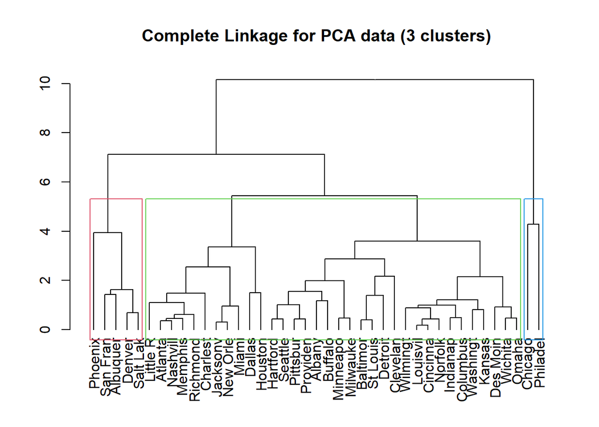

```r
plot(dend2_pca,main="Complete Linkage for PCA data (3 clusters)")
rect.hclust(hcpca2,k=3,border=2:4)
```

## Cophenetic Complete

**Cophenetic coefficient**

```r
clust_pca2 <- clustering(pca_cluster,distmethod = "euclidean",clustmethod = "complete")
clust_pca2$cophenetic
```

```
## [1] 0.7569114
```

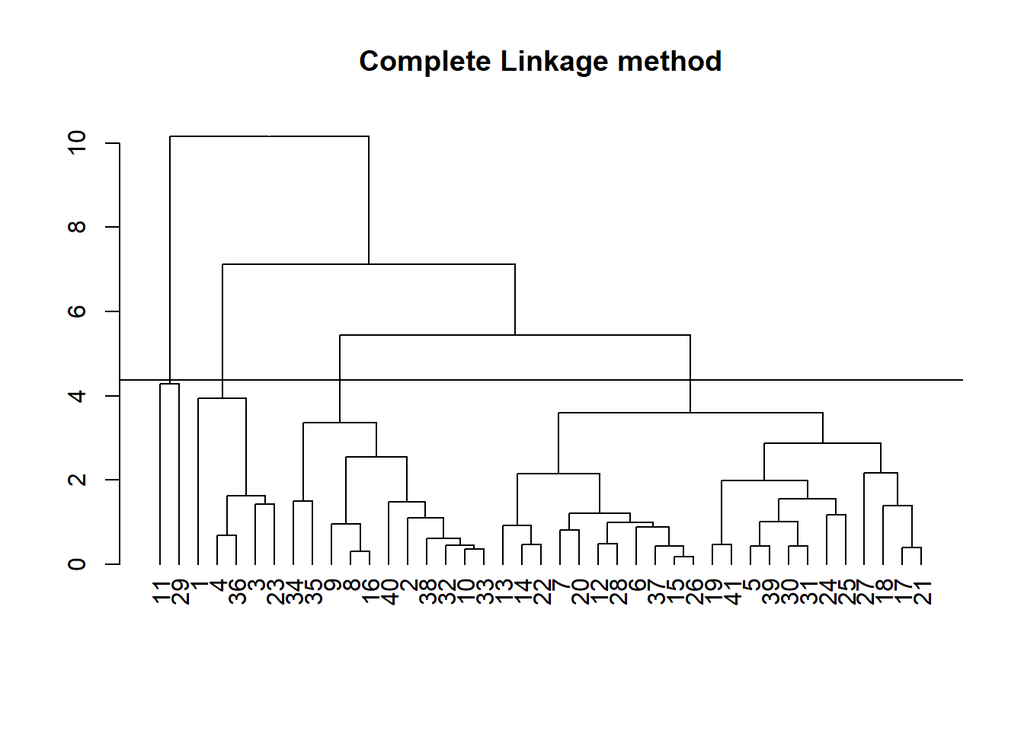

```r
plot(clust_pca2,horiz=FALSE,main="Complete Linkage method")
```

Considering 4 clusters:

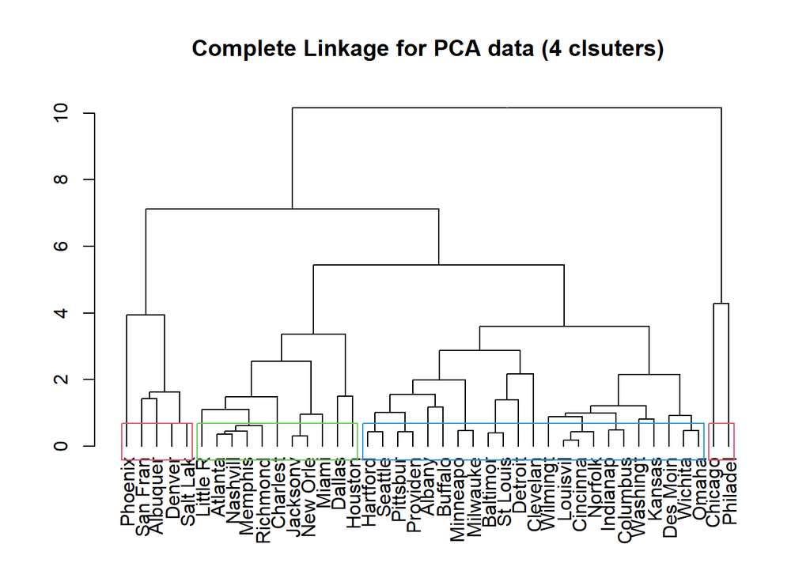

```r
order_in_dend <- order.dendrogram(dend2_pca)
labels(dend2_pca) <- data5$city[order_in_dend]
plot(dend2_pca,main="Complete Linkage for PCA data (4 clsuters)")
rect.hclust(hcpca2,k=4,border=2:4)
```

Finally, considering the number of optimal clusters given by the silhouette method:

```r
library(cluster)

# Choose the range of clusters to test
k_values <- 2:6

for (k in k_values) {
  # Cut dendrogram to get cluster assignments
  clusters <- cutree(dend2_pca, k = k)

  # Compute silhouette
  sil <- silhouette(clusters, dist_data5)

  # Average silhouette width
  avg_sil <- mean(sil[, 3])
  cat("k =", k, "Average silhouette width =", round(avg_sil, 3), "\n")
}
```

```
## k = 2 Average silhouette width = 0.509
## k = 3 Average silhouette width = 0.319
## k = 4 Average silhouette width = 0.255
## k = 5 Average silhouette width = 0.226
## k = 6 Average silhouette width = 0.209
```

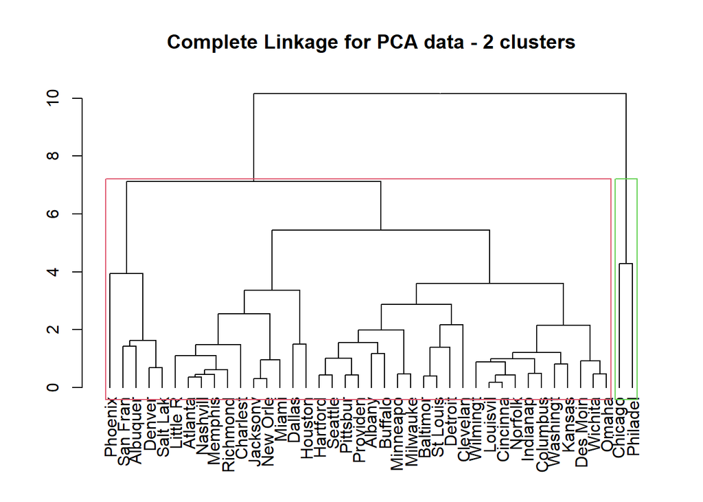

```r
order_in_dend <- order.dendrogram(dend2_pca)
labels(dend2_pca) <- data5$city[order_in_dend]
plot(dend2_pca,main="Complete Linkage for PCA data - 2 clusters")
rect.hclust(hcpca2,k=2,border=2:4)
```

The single method was better than the complete method.

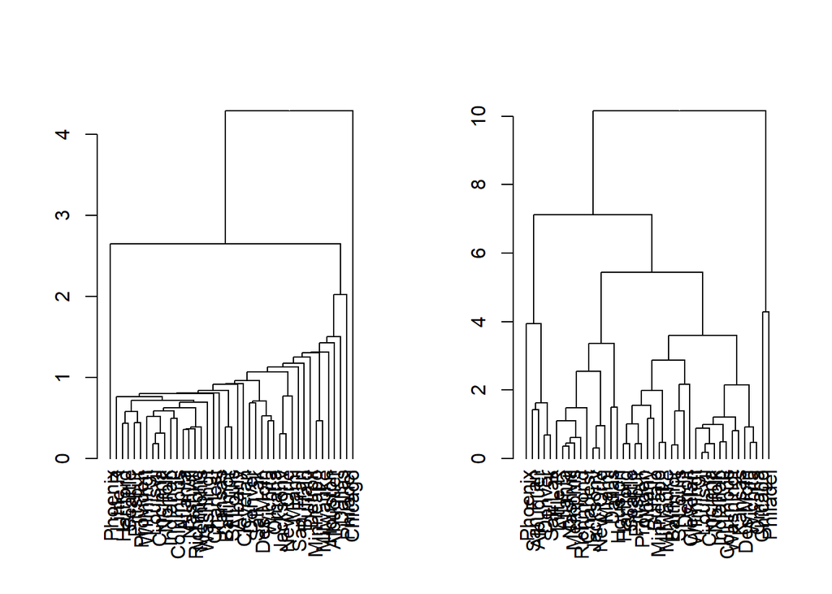

```r
par(mfrow=c(1,2))
plot(dend1_pca)
plot(dend2_pca)
```

```r
#plot(clust_pca,horiz=FALSE,main="Single Linkage")
#plot(clust_pca2,horiz=FALSE,main="Complete Linkage")
```